# Data Pre-Processing Exercises

```r
library(caret)
library(tidyverse)
library(AppliedPredictiveModeling)
library(mlbench)
library(corrplot)
```

# Finding the best EDA tools

## Correlation matrices / Scatter plots

```r
data(Glass)
data <- Glass

data$Type <- as.numeric(as.character(data$Type))
corrplot(cor(data), method = "number")
```

```r
chart.Correlation(data, histogram=TRUE)
```

```r
psych::pairs.panels(data,
  method = "pearson",
  hist.col = "#00AFBB",
  density = T,
  ellipses = F,
  smooth = F)
```

[output not shown]

We have 4 seemingly important predictors:

- Mg
- Al
- Na
- Ba

Relationships between predictors:

- Ca and Refractive index - Possibly, the added Calcium makes it cloudy as CaCo3 is very opaque.

```r
pairs(Glass)
```

The response variable glass type is a categorical variable, therefore linear regression is not applicable.

These initial plots are super important.

Skewed variables:

- Fe
- Ba
- K
- Mg is bimodal
- RI

Outliers: Negative values possibly, nothing to note.

There is a linear relationship between type and Si as well as Al.

I guess I could transform the variables with Box-Cox transformation but it won’t really do anything for tree-based models. I know centering and scaling features is important with neural nets but I don’t know if it also needs to be made closer to normal distribution.

**Is skewness a problem with neural networks?**

## Soybean data

```r
data("Soybean")
data <- Soybean
```

```r
str(data)
```

The dataset consists of a bunch of categorical variables one-hot encoded. It does not really help me understand the problem but so is data. This is a multiclass classification problem.

19 distinct plant disease classes.

Note to self: Continuous variables are much easier to interpret. This is a bit messy.

### Frequency distributions

```r
data_num <- sapply(data, as.numeric)

#cor(na.omit(data_num))
```

There were a few signs of degenerate categorical fequency distributions:

- There are very few instances in one of the two categories. If it’s a multiclass problem, there are very few instances in a class. (Near zero variance predictor)

I need to tally up the number and percentage of each classes. How is this done most efficiently if I don’t want to go over all 36 variables?

**Near zero variance**

```r
nearZeroVar(data)
```

Let’s examine these columns in detail.

```r
names(data[19])
names(data[26])
names(data[28])
```

```r
data %>% count(leaf.mild)
data %>% count(mycelium)
data %>% count(sclerotia)
```

```r
data %>% count(Class)
```

- Ratio of first to second is very high (20)
- Fraction of unique values over the sample size is low (10%)

### Correlation

```r
corrplot::corrplot(cor(na.omit(data_num)), method = "color", order = "hclust")
```

There are a number of correlated variables. These should / could be removed?

```r
high_cor <- findCorrelation(cor(na.omit(data_num)), cutoff = .75)
length(high_cor)
```

- Show NAs
- Show near 0 variance
- Show correlation plot / scatter plot

```r
summary(data)
```

```r
missing_col <- data %>%
gather(col, value) %>%
group_by(col) %>%
summarize(missing_share = mean(is.na(value))) %>%
arrange(desc(missing_share))

missing_col
```

```r
missing_col_within <-
data %>% filter(is.na(hail)) %>%
gather(col, value) %>%
group_by(col) %>%
summarize(missing_share = mean(is.na(value))) %>%
arrange(desc(missing_share))

missing_col_within
```

```r
missing_col %>% inner_join(missing_col_within, by = "col") %>% mutate(diff = missing_share.y - missing_share.x)
```

The conclusion is that it is definitely worth removing these missing values from the dataset as they are low quality across the board and introduce missing values in other places as well.

Steps

## Remove all missing Hail and go from there.

```r
# Remove missing hail rows
data <- data %>% filter(!is.na(hail))

# Test again
missing_col <- data %>%
gather(col, value) %>%
group_by(col) %>%
summarize(missing_share = mean(is.na(value))) %>%
arrange(desc(missing_share))

missing_col
```

Removing these instances absolutely eliminated my missing data issue. Good riddance. No need for imputation. If I were to impute, how would I do it? I did it with a linear model before. The mice package has really good tools for this.

# QSAR Data

```r
data(BloodBrain)
data <- bbbDescr
```

The solution is contained within logBBB.

The dataset contains 134 chemical characteristics. I think the jist of it all is that you don’t need to dig into veins and brain tissue to get samples, they are not easy to do. If you can predict the concentration based only on its chemical characteristics, you can design drugs much easier.

The point with such high number of predictors is that you’re not supposed to know what they mean and still come up with an effective machine learning model.

## Degenerate distributions

```r
nearZeroVar(data)
```

```
[1]  3 16 17 22 25 50 60
```

## Missingness

```r
data %>%
gather(col, value) %>%
group_by(col) %>%
summarize(missing_share = mean(is.na(value))) %>%
arrange(desc(missing_share))
```

| col | missing_share |
| --- | --- |
| a_acc | 0 |
| a_acid | 0 |
| a_aro | 0 |
| a_base | 0 |
| achg | 0 |
| adistd | 0 |
| adistm | 0 |
| alert | 0 |
| andrewbind | 0 |
| chaa1 | 0 |

[output cut: 124 more lines]

There is no missing data. Amazing!

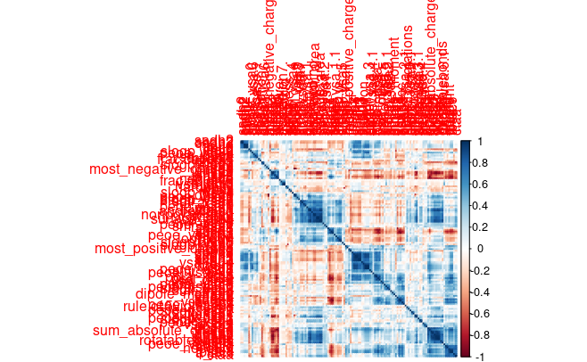

```r
corrplot::corrplot(cor(data), method = "color", order = "hclust")
```

A clear candidate for this is PCA.

```r
findCorrelation(cor(data), cutoff = 1) %>% length()
```

```
[1] 0
```

There is no variable perfectly correlated.

```r
cols_to_delete <- findCorrelation(cor(data), cutoff = 0.75)
findCorrelation(cor(data), cutoff = 0.75) %>% length()
```

```
[1] 66
```

66 variables have a correlation coefficient higher than 0.75. These could be removed.

```r
filtered_data <- data[, -cols_to_delete]
```

And thus, 68 variables remain.

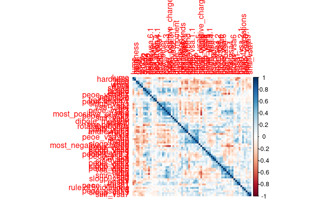

```r
corrplot::corrplot(cor(filtered_data), method = "color", order = "hclust")
```

```r
nearZeroVar(filtered_data)
```

```
[1]  2 13 14 18 35 42
```

```r
filtered_data <- filtered_data[, -nearZeroVar(filtered_data)]
filtered_data <- data.frame(logBBB, filtered_data)
```

This method is now finished.

## Principal Coefficient Analysis

PCA is sensitive to skewed data as well as data on different scales. Therefore, it is a must to trasnsform, scale and center the data before PCA.

```r
pca_object <- prcomp(data, center = T, scale. = T)
```

```r
library(e1071)
trans <- preProcess(data,
                    method = c("BoxCox", "center", "scale", "pca"))
```

```r
trans
```

```
Created from 208 samples and 134 variables

Pre-processing:
  - Box-Cox transformation (40)
  - centered (134)
  - ignored (0)
  - principal component signal extraction (134)
  - scaled (134)

Lambda estimates for Box-Cox transformation:
   Min. 1st Qu.  Median    Mean 3rd Qu.    Max.
 -2.000  -0.150   0.150   0.050   0.425   2.000

PCA needed 31 components to capture 95 percent of the variance
```

This is very consistent with the correlation removal method. 31 components encode 62 of the variables. It’s very good that 95% of the variance is accounted for.

I really like this. The dimensionality is now reduced to only 31 principal coefficients. It’s not interpretable now at all but it’s so numerically pure.

Question: Which coefficients were used? In what order?